# Notebook Structure

1. Import necessary dependencies
2. Import the required dataset
3. Visualize different columns using Frequency plot
4. How to interpret Frequency plot

# 1. Import necessary dependencies

```python
# libraries & dataset
import matplotlib.pyplot as plt
import seaborn as sns

sns.set_theme(style="darkgrid")
```

# 2. Import the required dataset

```python
# Load the titanic dataset
df = sns.load_dataset('titanic')
```

```python
df.head()
```

|  | survived | pclass | sex | age | sibsp | parch | fare | embarked | class | who | adult_male | deck | embark_town | alive | alone |
| --- | --- | --- | --- | --- | --- | --- | --- | --- | --- | --- | --- | --- | --- | --- | --- |
| 0 | 0 | 3 | male | 22.0 | 1 | 0 | 7.2500 | S | Third | man | True | NaN | Southampton | no | False |
| 1 | 1 | 1 | female | 38.0 | 1 | 0 | 71.2833 | C | First | woman | False | C | Cherbourg | yes | False |
| 2 | 1 | 3 | female | 26.0 | 0 | 0 | 7.9250 | S | Third | woman | False | NaN | Southampton | yes | True |
| 3 | 1 | 1 | female | 35.0 | 1 | 0 | 53.1000 | S | First | woman | False | C | Southampton | yes | False |
| 4 | 0 | 3 | male | 35.0 | 0 | 0 | 8.0500 | S | Third | man | True | NaN | Southampton | no | True |

# 3. Visualize different columns

### A. Drawing a simple frequency plot with default parameters

```
  Embarked  Frequency  Percentage
0        S        644   72.278339
1        C        168   18.855219
2        Q         77    8.641975
```

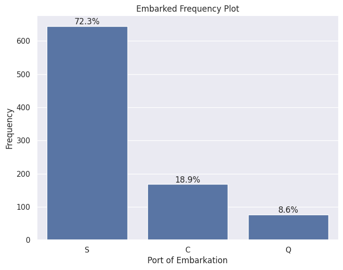

```python
# Get the value counts of the 'Embarked' column
embarked_counts = df['embarked'].value_counts().reset_index()
embarked_counts.columns = ['Embarked', 'Frequency']  # Rename for clarity

# Calculate percentages for the frequency table
embarked_counts['Percentage'] = (embarked_counts['Frequency'] / len(df)) * 100

# Print the frequency table
print(embarked_counts)

# Create a bar plot
plt.figure(figsize=(8, 6))  # Adjust figure size as needed
sns.barplot(x='Embarked', y='Frequency', data=embarked_counts)

# Add a title and labels
plt.title('Embarked Frequency Plot')
plt.xlabel('Port of Embarkation')
plt.ylabel('Frequency')

# Add percentage labels on the bars
for index, row in embarked_counts.iterrows():
    plt.text(row.Embarked, row.Frequency, f'{row.Percentage:.1f}%', ha='center', va='bottom')

# Show the plot
plt.show()
```

### B. Visualize multiple frequency plots

1. Update the columns that you want to visualize
2. Update the colors of the bar
3. Update the num_cols
4. update the figsize

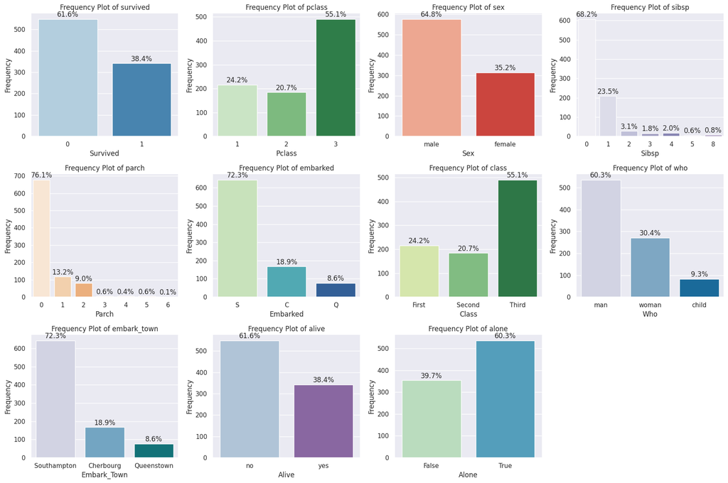

```python
# Define the columns to plot
columns_to_plot = ['survived', 'pclass', 'sex', 'sibsp', 'parch', 'embarked', 'class', 'who', 'embark_town', 'alive', 'alone']

# Define a list of color palettes
color_palettes = ['Blues', 'Greens', 'Reds', 'Purples', 'Oranges', 'YlGnBu', 'YlGn', 'PuBu', 'PuBuGn', 'BuPu', 'GnBu']

# Determine the number of rows and columns for the subplot grid
num_cols = 4
num_rows = (len(columns_to_plot) + num_cols - 1) // num_cols  # Ensure enough rows

# Create the subplots
fig, axes = plt.subplots(num_rows, num_cols, figsize=(18, 12))
axes = axes.flatten()

# Iterate through the columns and plot each one in a separate subplot
for i, col in enumerate(columns_to_plot):
    # Select the appropriate subplot axis
    ax = axes[i]

    # Use a different color palette for each bar plot
    palette = color_palettes[i % len(color_palettes)]  # Cycle through palettes

    # Create the bar plot using countplot with the selected palette
    sns.countplot(x=col, data=df, ax=ax, palette=palette)

    # Add a title and labels
    ax.set_title(f"Frequency Plot of {col}")
    ax.set_xlabel(col.title())
    ax.set_ylabel("Frequency")

    # Add percentage labels on the bars
    total = len(df[col])
    for p in ax.patches:
        height = p.get_height()
        ax.text(p.get_x() + p.get_width() / 2., height + 3, f'{100 * height / total:.1f}%', ha='center', va='bottom')

# Remove any unused subplots
if len(columns_to_plot) < num_rows * num_cols:
    for j in range(len(columns_to_plot), num_rows * num_cols):
        fig.delaxes(axes[j])

# Adjust the layout to prevent overlapping titles/labels
plt.tight_layout()

# Show the plots
plt.show()
```

# 4. How to Interpret Frequency plot :

Key Features to Look For :

- Bars: The plot consists of bars, each representing a category.
- Bar Height: The height of each bar corresponds to the frequency (count) of observations in that category. Taller bars indicate higher frequencies.
- Categories: The x-axis displays the categories being analyzed.
- Frequency: The y-axis represents the frequency (count) of observations for each category.
- Colors: Different colors may be used to distinguish between bars or highlight specific categories.

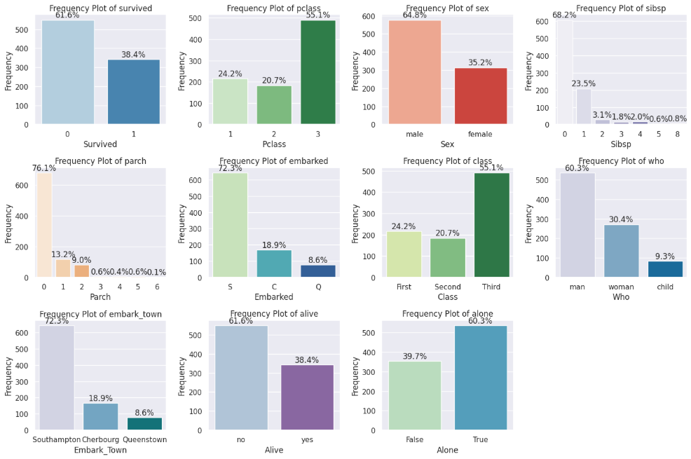

Frequency Plot of Survived

- Categories: 0 (Did not survive), 1 (Survived)
- Bar Heights: The bar for '0' is taller than the bar for '1'.
- Frequency: The y-axis shows the number of passengers.
- Observations: A greater number of passengers did not survive compared to those who did.

Frequency Plot of Pclass

- Categories: 1, 2, 3 (Passenger Class)
- Bar Heights: The bar for '3' is the tallest, followed by '1', and then '2'.
- Frequency: The y-axis shows the number of passengers.
- Observations: Most passengers were in the third class, followed by the first class, and the fewest in the second class.

Frequency Plot of Sex

- Categories: male, female
- Bar Heights: The bar for 'male' is taller than the bar for 'female'.
- Frequency: The y-axis shows the number of passengers.
- Observations: There were more male passengers than female passengers.

Frequency Plot of Sibsp

Frequency Plot of Parch

Frequency Plot of Embarked

- Categories: S, C, Q (Port of Embarkation)
- Bar Heights: The bar for 'S' is the tallest, followed by 'C', and then 'Q'.
- Frequency: The y-axis shows the number of passengers.
- Observations: Most passengers embarked at Southampton (S), followed by Cherbourg (C), and the fewest at Queenstown (Q).

Frequency Plot of Class

- Categories: First, Second, Third (Passenger Class)
- Bar Heights: The bar for 'Third' is the tallest, followed by 'First', and then 'Second'.
- Frequency: The y-axis shows the number of passengers.
- Observations: Most passengers were in the third class, followed by the first class, and the fewest in the second class.

Frequency Plot of Who

- Categories: man, woman, child
- Bar Heights: The bar for 'man' is the tallest, followed by 'woman', and then 'child'.
- Frequency: The y-axis shows the number of passengers.
- Observations: There were more male passengers than female passengers, and the fewest were children.

Frequency Plot of Embark_town

- Categories: Southampton, Cherbourg, Queenstown (Port of Embarkation)
- Bar Heights: The bar for 'Southampton' is the tallest, followed by 'Cherbourg', and then 'Queenstown'.
- Frequency: The y-axis shows the number of passengers.
- Observations: Most passengers embarked at Southampton, followed by Cherbourg, and the fewest at Queenstown.

Frequency Plot of Alive

- Categories: no, yes (Survival Status)
- Bar Heights: The bar for 'no' is taller than the bar for 'yes'.
- Frequency: The y-axis shows the number of passengers.
- Observations: A greater number of passengers did not survive compared to those who did.

Frequency Plot of Alone

- Categories: False, True (Traveling Alone)
- Bar Heights: The bar for 'True' is taller than the bar for 'False'.
- Frequency: The y-axis shows the number of passengers.
- Observations: More passengers were traveling alone than those who were not.